# Marathonbet’s accuracy in predicting sumo results

Mikhail Zhilkin

2017-04-16

The only packages we’ll need are [ROCR](https://cran.r-project.org/web/packages/ROCR/index.html) (to measure prediction accuracy) and [tidyverse](https://cran.r-project.org/web/packages/tidyverse/index.html) (for everything else — [tidyverse.org](http://tidyverse.org/)):

```r
library(ROCR)
library(tidyverse)
```

Marathonbet started offering bets on Makuuchi bouts. I’ve collected the odds for January and March tournaments from betmarathon.com/en/betting/Sumo/ (available only during Honbasho):

```r
odds <- read_csv("odds.csv", col_types = "cicdcd")
odds %>% arrange(basho, day)
```

| basho | day | rikishi1 | odds1 | rikishi2 | odds2 |
| --- | --- | --- | --- | --- | --- |
| 2017.01 | 2 | Aoiyama | 2.150000 | Chiyonokuni | 1.700000 |
| 2017.01 | 2 | Chiyoshoma | 2.150000 | Myogiryu | 1.700000 |
| 2017.01 | 2 | Endo | 2.380000 | Ikioi | 1.580000 |
| 2017.01 | 2 | Hakuho | 1.070000 | Takarafuji | 8.500000 |
| 2017.01 | 2 | Harumafuji | 1.280000 | Mitakeumi | 3.680000 |
| 2017.01 | 2 | Hokutofuji | 1.900000 | Kaisei | 1.900000 |
| 2017.01 | 2 | Ichinojo | 1.480000 | Chiyotairyu | 2.650000 |
| 2017.01 | 2 | Ishiura | 2.150000 | Sokokurai | 1.700000 |
| 2017.01 | 2 | Kagayaki | 2.340000 | Takanoiwa | 1.600000 |
| 2017.01 | 2 | Kakuryu | 1.080000 | Shohozan | 7.900000 |

[output cut: 531 more lines]

I’d missed the first day of the January tournament, and asked the customer service if there was an archive with historical odds. No:

> Please be aware that this option is not available.  
> Due to the odds are movement depents of the fluctuations of the market.

Anyway, 541 bouts should be enough for our purposes:

```r
odds %>% count(basho, day)
```

| basho | day | n |
| --- | --- | --- |
| 2017.01 | 2 | 19 |
| 2017.01 | 3 | 18 |
| 2017.01 | 4 | 19 |
| 2017.01 | 5 | 18 |
| 2017.01 | 6 | 18 |
| 2017.01 | 7 | 20 |
| 2017.01 | 8 | 18 |
| 2017.01 | 9 | 19 |
| 2017.01 | 10 | 19 |
| 2017.01 | 11 | 18 |

[output cut: 19 more lines]

Results for all divisions are easily fetched from [Sumo Reference](http://sumodb.sumogames.de/) (day 16 stands for play-offs):

```r
results <- read_csv("results.csv", col_types = "cicicic")
results %>% count(basho, day)
```

| basho | day | n |
| --- | --- | --- |
| 2017.01 | 1 | 166 |
| 2017.01 | 2 | 172 |
| 2017.01 | 3 | 173 |
| 2017.01 | 4 | 172 |
| 2017.01 | 5 | 174 |
| 2017.01 | 6 | 173 |
| 2017.01 | 7 | 168 |
| 2017.01 | 8 | 167 |
| 2017.01 | 9 | 167 |
| 2017.01 | 10 | 166 |

[output cut: 22 more lines]

To join *odds* with *results*:

1. As they don’t necessarily order wrestlers (*rikishi1*, *rikishi2*) in the same way, join *odds* with a mirrored copy of itself.
2. Calculate implied probability of the first wrestler winning.
3. Filter out forfeits (see fusen).

```r
odds_and_results <- merge(
    rbind(
        odds,
        odds %>% rename(
            rikishi1 = rikishi2, odds1 = odds2,
            rikishi2 = rikishi1, odds2 = odds1
        )
    ) %>% mutate(win1_prob = odds2 / (odds1 + odds2)),
    results %>% filter(kimarite != "fusen")
)
odds_and_results
```

| basho | day | rikishi1 | rikishi2 | odds1 | odds2 | win1_prob | win1 | win2 | kimarite |
| --- | --- | --- | --- | --- | --- | --- | --- | --- | --- |
| 2017.01 | 10 | Chiyoo | Aoiyama | 2.220000 | 1.660000 | 0.4278351 | 1 | 0 | uwatenage |
| 2017.01 | 10 | Chiyootori | Nishikigi | 1.800000 | 2.010000 | 0.5275591 | 1 | 0 | shitatenage |
| 2017.01 | 10 | Chiyoshoma | Ishiura | 1.840000 | 1.960000 | 0.5157895 | 0 | 1 | okuritaoshi |
| 2017.01 | 10 | Ikioi | Hakuho | 5.300000 | 1.160000 | 0.1795666 | 0 | 1 | tsukiotoshi |
| 2017.01 | 10 | Kaisei | Yoshikaze | 1.800000 | 2.010000 | 0.5275591 | 0 | 1 | shitatedashinage |
| 2017.01 | 10 | Kakuryu | Tamawashi | 1.330000 | 3.320000 | 0.7139785 | 0 | 1 | tsukidashi |
| 2017.01 | 10 | Kisenosato | Terunofuji | 1.450000 | 2.760000 | 0.6555819 | 1 | 0 | yorikiri |
| 2017.01 | 10 | Kotoshogiku | Goeido | 1.960000 | 1.840000 | 0.4842105 | 0 | 1 | katasukashi |
| 2017.01 | 10 | Mitakeumi | Shodai | 1.650000 | 2.240000 | 0.5758355 | 1 | 0 | yoritaoshi |
| 2017.01 | 10 | Myogiryu | Daishomaru | 1.600000 | 2.340000 | 0.5939086 | 0 | 1 | tsukiotoshi |

[output cut: 524 more lines]

Sanity check — what’s the distribution of implied probability to win for winner and losers?

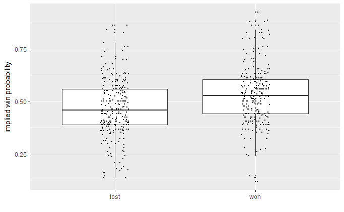

```r
ggplot(odds_and_results, aes(factor(win1, labels = c("lost", "won")), win1_prob)) +
    geom_boxplot(outlier.size = .5) +
    geom_jitter(size = .5, width = .1) +
    labs(x = "", y = "implied win probability")
```

To measure prediction accuracy, we’ll use [ROC curve](http://mlwiki.org/index.php/ROC_Analysis#ROC_Analysis_in_R):

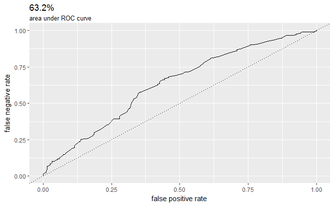

```r
pred <- prediction(
    predictions = odds_and_results$win1_prob,
    labels = odds_and_results$win1
)
perf <- performance(pred, measure = "tpr", x.measure = "fpr")
ggplot(data.frame(x = perf@x.values[[1]], y = perf@y.values[[1]]), aes(x, y)) +
    geom_line() +
    labs(
        title = sprintf("%.1f%%", unlist(performance(pred, "auc")@y.values) * 100),
        subtitle = "area under ROC curve",
        x = "false positive rate",
        y = "false negative rate"
    ) +
    geom_abline(intercept = 0, slope = 1, linetype = "dotted")
```